# Drug-Induced Phenotypes

Jan Sauer and Niklas Rindtorff

2022-03-24

Updating key objects after removing data from the analysis

```r
drug_effect_metadata_all_lines <- drug_effect_metadata
drug_effect_metadata_filtered <- drug_effect_metadata %>% filter(!Line %in% c("D021T01", "D054T01", "D055T01"))
# drug_effect_metadata <- drug_effect_metadata %>% filter(!Line %in% c("D021T01", "D054T01", "D055T01"))
```

# Introduction

Drug effects are defined as the vector pointing from negative control (DMSO) organoids to treated organoids in feature space. Features are transformed with a PCA and the top 25 components are retained. A logistic regression model is trained to differentiate DMSO and treated organoids (for each drug individually) and the normal vector to the separating hyperplane is defined as the drug effect vector. It is scaled to be as long as the distance between the DMSO median and the treated organoid median in feature space.

The paper’s “story flow” began with the drug-induced phenotypes and then continued onto the organoid viability. However, there are interesting parallels between the two analyses so that I include the lethality of drugs in the annotation of heatmaps here.

# Define Active Drugs

A histogram of the accuracies (or AUCs to be exact) shows that there are two groups of drugs. The first, normally distributed, group with low AUCs represents the inactive drugs that cannot be sufficiently differentiated from DMSO while the other group represents the active drugs that have significantly different characteristic features than the DMSO organoids and can be separated by a linear SVM hyperplane in feature space.

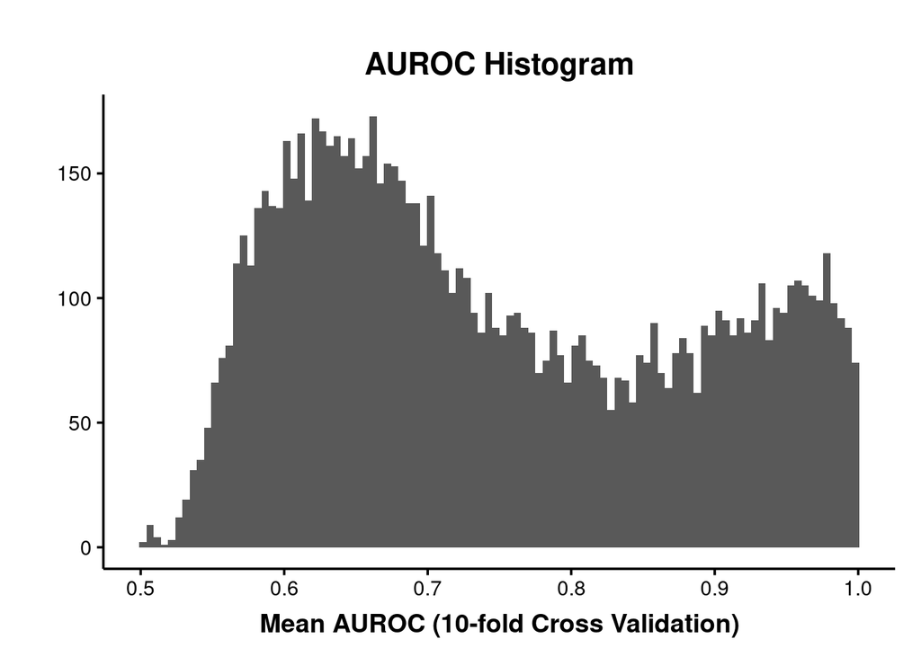

```r
ggplot(data = drug_effect_metadata_filtered, mapping = aes(x = AUC_Mean)) +
  geom_histogram(bins = 100) +
  theme_vignette() + ggtitle("AUROC Histogram") +
  xlab("Mean AUROC (10-fold Cross Validation)") + ylab("") +
if(save_images) ggsave(
  filename = file.path(img_out_dir, "Histogram_ClassifierAUCs.pdf"),
  width = 3, height = 3, useDingbats = FALSE)
```

The distance in feature space between drugs and DMSO clouds correlates, as expected, with the AUROC.

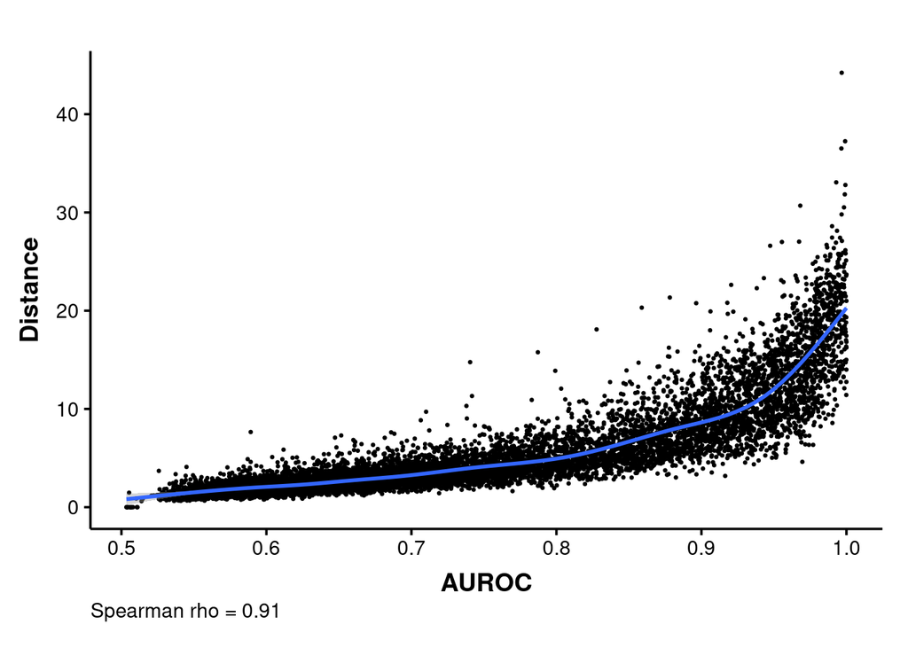

```r
ggplot(data = drug_effect_metadata_filtered,
       mapping = aes(x = AUC_Mean, y = Distance)) +
  geom_point(size = 0.5) +
  theme_vignette() + labs(
    caption = paste("Spearman rho =", round(
      cor(drug_effect_metadata_filtered$AUC_Mean,
          drug_effect_metadata_filtered$Distance, method = "spearman"), 2))) +
  xlab("AUROC") + labs(color = "") +
  geom_smooth()
```

```r
if(save_images) ggsave(
  filename = file.path(img_out_dir, "Scatterplot_AUCvsDistance.pdf"),
  width = 3, height = 3, useDingbats = FALSE)
```

The SVM was trained with 10-fold cross validation and the resulting means and standard devations of the accuracies are shown below.

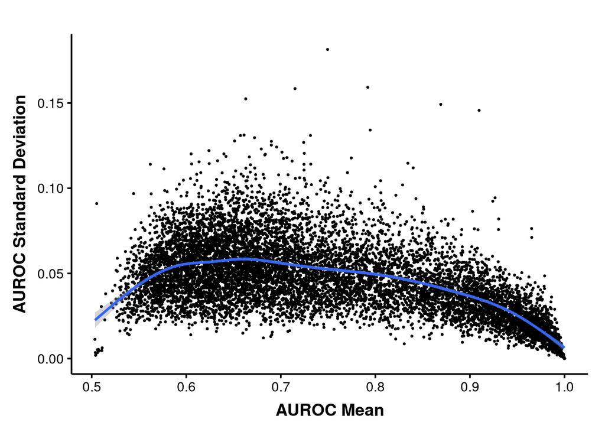

```r
ggplot(data = drug_effect_metadata_filtered,
       mapping = aes(x = AUC_Mean, y = AUC_Std)) +
  geom_point(size = 0.5) + theme_vignette() +
  labs(x = "AUROC Mean", y = "AUROC Standard Deviation", color = "") +
  geom_smooth()
```

```r
if(save_images) ggsave(
  filename = file.path(img_out_dir, "Scatterplot_AUCMeanvsAUCStd.pdf"),
  width = 3, height = 3, useDingbats = FALSE)
```

Based on the bimodal histogram of active drugs, I define any drug that can be separated with $AUC = 0.85$ from the DMSO controls as “active”.

```r
auc_thresh = 0.85
profiles_active = drug_effect_metadata_all_lines[drug_effect_metadata_all_lines$AUC_Mean >= auc_thresh, ]
metadata_active = drug_effect_metadata_all_lines[drug_effect_metadata_all_lines$AUC_Mean >= auc_thresh, ]

profiles_active_filtered = drug_effect_metadata_filtered[drug_effect_metadata_filtered$AUC_Mean >= auc_thresh, ]
metadata_active_filtered = drug_effect_metadata_filtered[drug_effect_metadata_filtered$AUC_Mean >= auc_thresh, ]
```

The number of active drugs varies per line.

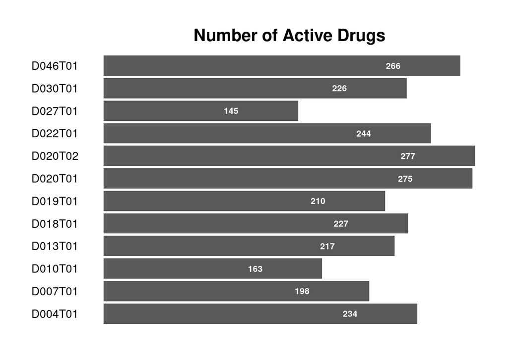

```r
ggplot_df = as.data.frame(table(metadata_active_filtered$Line))
# D054T01 was only imaged with the small library
ggplot_df = ggplot_df[ggplot_df$Var1 != "D054T01", ]

# filtering additional lines
ggplot_df <- ggplot_df %>%
  dplyr::filter(!Var1 %in% c("D021T01", "D055T01"))

ggplot_df %>% write_csv(here::here("reports/tables/source_data_Barplot_NumActiveDrugs_3b.csv"))

ggplot_df$TextLoc = ggplot_df$Freq - 50
ggplot(data = ggplot_df, mapping = aes(x = Var1, y = Freq)) +
  geom_col() +
  geom_text(mapping = aes(x = Var1, y = TextLoc, label = Freq),
            color = "white", fontface = "bold", size = 3) +
  theme_vignette() +
  theme(axis.line = element_blank(), axis.text.x = element_blank(),
        axis.ticks = element_blank()) +
  xlab("") + ylab("") + ggtitle("Number of Active Drugs") +
  coord_flip()
```

```r
if(save_images) ggsave(
  filename = file.path(img_out_dir, "Barplot_NumActiveDrugs.pdf"),
  width = 2.5, height = 3)
```

Some drugs are active in all cell lines and others only in very few.

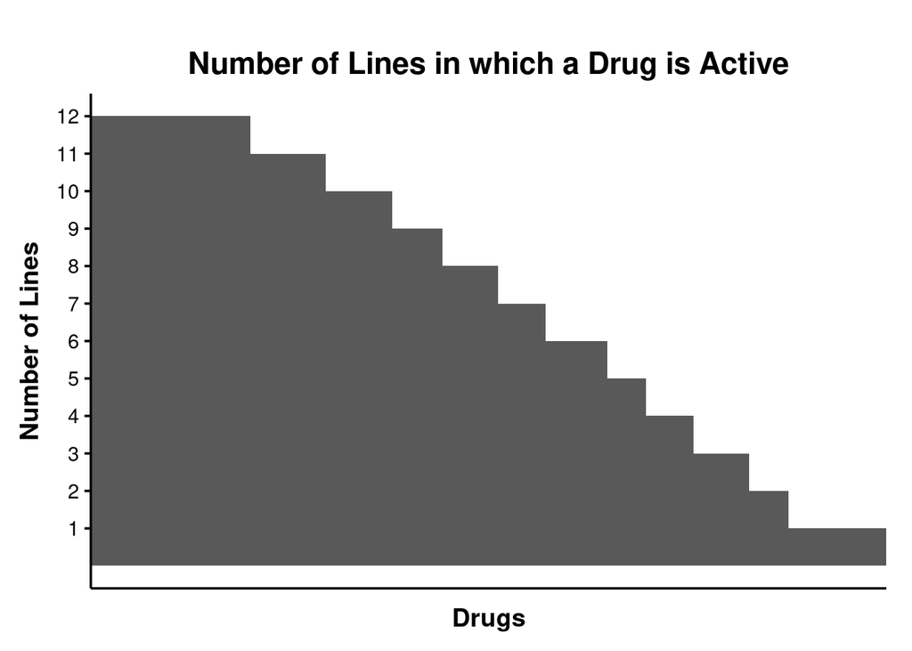

```r
activity_table = table(metadata_active_filtered$Drug, metadata_active_filtered$Line)
activity_table = activity_table[, colnames(activity_table) != "D054T01"]
ggplot_df = as.data.frame(sort(rowSums(activity_table > 0), decreasing = TRUE))

colnames(ggplot_df) = "Freq"
ggplot_df$Var1 = factor(rownames(ggplot_df), levels = rownames(ggplot_df))
ggplot(data = ggplot_df, mapping = aes(x = Var1, y = Freq)) +
  geom_col(width = 1) + theme_vignette() + theme(
    axis.text.x = element_blank(), axis.ticks.x = element_blank()) +
  xlab("Drugs") + ylab("Number of Lines") +
  ggtitle("Number of Lines in which a Drug is Active") +
  scale_y_continuous(breaks = seq_len(length(lines)))
```

A comparison of the viability versus the drug effect shows that all drugs previously identified as lethal are also identified as active. However, a good number of active drugs were previously identified as nonlethal.

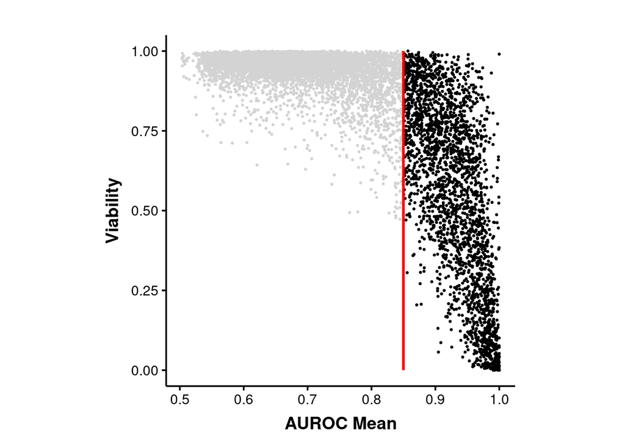

```r
ggplot(mapping = aes(y = Viability, x = AUC_Mean)) +
  geom_point(data = drug_effect_metadata_filtered, color = "lightgrey", size = 0.5) +
  geom_point(data = drug_effect_metadata_filtered[
    drug_effect_metadata_filtered$AUC_Mean >= auc_thresh, ],
             size = 0.5) +
  theme_vignette() + ylab("Viability") + xlab("AUROC Mean") +
  geom_segment(mapping = aes(
      y = 0, yend = 1, x = auc_thresh, xend = auc_thresh),
    color = "red", size = 1) + coord_equal(ratio = 0.5)
```

```r
if(save_images) ggsave(
  filename = file.path(img_out_dir, "Scatterplot_ViabilityVsSVMAUROC.pdf"),
  width = 3, height = 3, useDingbats = FALSE)
```

Plotting a histogram of the viabilities of all “active” drugs, i.e. with $AUROC \geq 0.85$

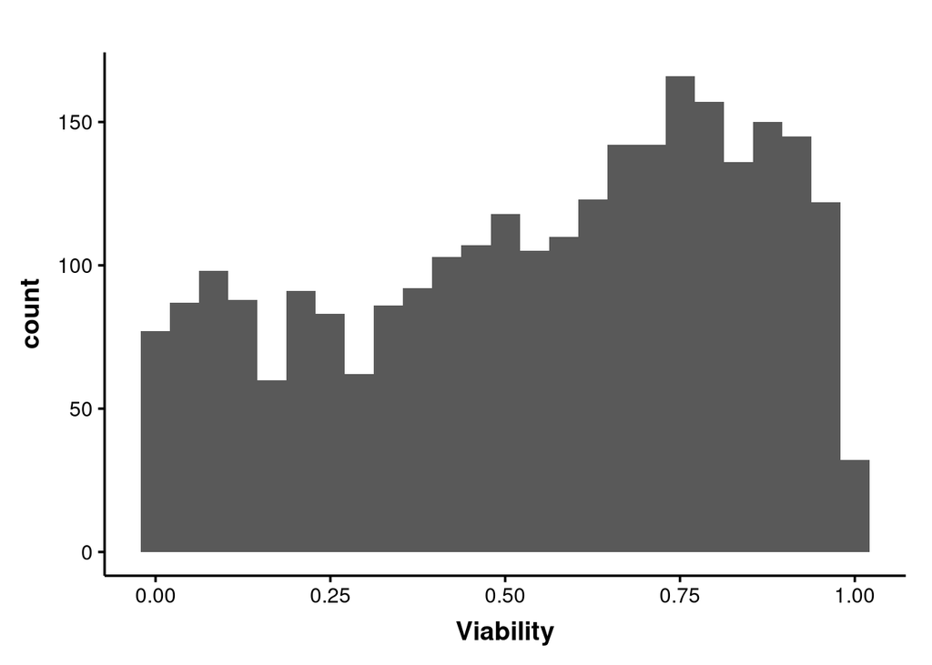

```r
ggplot(data = drug_effect_metadata_filtered[
  drug_effect_metadata_filtered$AUC_Mean >= auc_thresh, ]) +
  geom_histogram(mapping = aes(x = Viability), bins = 25) +
  theme_vignette()
```

# KiStem library

I analyze the two libraries separately and begin with the KiStem library.

```r
sel_indices = (is.na(drug_effect_metadata_all_lines$Concentration) | (
  drug_effect_metadata_all_lines$Drug %in% c("Bortezomib", "Irinotecan / SN-38") &
  drug_effect_metadata_all_lines$Concentration %in% c(0.2, 1))) &
  # D054 was only treated with the CCP library
  drug_effect_metadata_all_lines$Line != "D054T01"
profiles = drug_effect_profiles[sel_indices, ]
metadata = drug_effect_metadata_all_lines[sel_indices, ]
```

```r
sel_indices = metadata$AUC_Mean >= auc_thresh
profiles_active = profiles[sel_indices, ]
metadata_active = metadata[sel_indices, ]
```

## Individual Cell Lines

I look at the angles between vectors. The classification generates a profile for all drugs, including inactive ones. However, because they cannot be properly separated from DMSO, the profiles of these drugs will be largely random, ergo I remove them as noise.

```r
killing_anno = rep(NA, nrow(metadata_active))
killing_anno[metadata_active$Viability <= 0.2] = "0.2"
killing_anno[
  metadata_active$Viability > 0.2 &
  metadata_active$Viability <= 0.4] = "0.4"
killing_anno[
  metadata_active$Viability > 0.4 &
  metadata_active$Viability <= 0.6] = "0.6"
killing_anno[
  metadata_active$Viability > 0.6 &
  metadata_active$Viability <= 0.8] = "0.8"
killing_anno[
  metadata_active$Viability > 0.8 &
  metadata_active$Viability <= 1] = "1"

annotation = data.frame(
  "Viability" = killing_anno,
  "Pathway" = SCOPEAnalysis::get_mode_of_action(metadata_active$Drug),
  "Target" = SCOPEAnalysis::get_targets(metadata_active$Drug),
  "Line" = metadata_active$Line,
  row.names = rownames(profiles_active), # needs commenting when filtering
  stringsAsFactors = FALSE)

# Fix for slashes in targets
annotation$Target = gsub(
  pattern = "/", replacement = ", ", annotation$Target)

# Calculate the angles for each line
line_results = list()
enriched_drugs = list()
oddsratio_pathway = list()
oddsratio_target = list()
for(line in unique(substr(rownames(annotation), 1, 7))) {
  line_sel_indices = annotation$Line == line
  line_annotation = annotation[line_sel_indices, ]
  line_annotation$Line = NULL
  line_profiles = profiles_active[line_sel_indices, ]
  line_metadata = metadata_active[line_sel_indices, ]

  # Calc angles and cluster
  angles = get_angles(line_profiles)
  if(nrow(angles) < 2) next
  d = acos(angles)*180/pi
  hc = hclust(as.dist(d), method = "ward.D2")

  # Also cluster the principal components by correlation just for kicks
  cor_pca = cor(line_profiles)
  d_pca = as.dist((1 - cor_pca) / 2)
  hc_pca = hclust(d_pca, method = "ward.D2")

  # Annotate Pathway and Targets
  pathways = list()
  for(pathway in unique(line_annotation$Pathway)) {
    pathways[[pathway]] = grep(
      pattern = paste0("\\b", pathway, "\\b"),
      x = line_annotation$Pathway,
      ignore.case = TRUE)
  }
  # My cluster_enrichment function doesn't play well with NA values yet
  pathways = pathways[!is.na(names(pathways))]
  pathways_sig_vec = get_cluster_enrichment(
    clustering = hc, labels = pathways, min_cluster_size = min_cluster_size)
  # 'Others' is too vague
  pathways_sig_vec$Labels[pathways_sig_vec$Labels == "Others"] = NA

  targets_split = tolower(line_annotation$Target)
  targets = list()
  for(target in unique(unlist(strsplit(targets_split, ", ")))) {
    targets[[target]] = grep(
      pattern = paste0("\\b", target, "\\b"),
      x = targets_split, ignore.case = TRUE)
  }
  # My cluster_enrichment function doesn't play well with NA values yet
  targets = targets[!is.na(names(targets))]
  targets_sig_vec = get_cluster_enrichment(
    clustering = hc, labels = targets, min_cluster_size = min_cluster_size)

  line_annotation$Pathway = pathways_sig_vec$Labels
  line_annotation$Target = targets_sig_vec$Labels

  enriched_drugs[[line]] = data.frame(
    "Drug" = substr(rownames(line_annotation), 9, 100000L),
    "Line" = line,
    "Pathway" = annotation[annotation$Line == line, "Pathway"],
    "Target" = annotation[annotation$Line == line, "Target"],
    "Enriched.Target" = line_annotation$Target,
    "is.pathway.enriched" = !is.na(line_annotation$Pathway),
    "is.target.enriched" = !is.na(line_annotation$Target),
    stringsAsFactors = FALSE)

  if(nrow(pathways_sig_vec$Fisher.Test) > 0) {
    oddsratio_pathway[[line]] = cbind.data.frame(
      "Line" = line, pathways_sig_vec$Fisher.Test)
  }
  if(nrow(targets_sig_vec$Fisher.Test) > 0) {
    oddsratio_target[[line]] = cbind.data.frame(
      "Line" = line, targets_sig_vec$Fisher.Test)
  }

  line_results[[line]] = list(
    "Annotation" = line_annotation,
    "Distances" = d,
    "Clustering" = hc,
    "PCAClustering" = hc_pca)
}
```

```r
# Save enriched drugs
enriched_drugs = do.call(rbind, enriched_drugs)
rownames(enriched_drugs) = NULL
if(save_images) write.csv2(
  x = enriched_drugs, file = "EnrichedDrugs.csv",
  quote = FALSE, row.names = FALSE)

# Save oddsratio Ratios
oddsratio_pathway = do.call(rbind, oddsratio_pathway)
rownames(oddsratio_pathway) = NULL
if(save_images) write.csv2(
  x = oddsratio_pathway, file = "OddsRatio_Pathways.csv",
  quote = FALSE, row.names = FALSE)
oddsratio_target = do.call(rbind, oddsratio_target)
rownames(oddsratio_target) = NULL
if(save_images) write.csv2(
  x = oddsratio_target, file = "OddsRatio_Target.csv",
  quote = FALSE, row.names = FALSE)
```

```r
anno_colorScale = list(
  "Viability" = setNames(
    object = grDevices::colorRampPalette(c("black", "white"))(
      length(unique(annotation$Viability))),
    nm = sort(unique(annotation$Viability))))

# Plot all results
for(line in names(line_results)) {
  line_annotation = line_results[[line]]$Annotation
  line_profiles = profiles_active[annotation$Line == line,]
  line_color = anno_colorScale
  if(sum(!is.na(line_annotation$Pathway)) == 0) line_annotation$Pathway = NULL
  if(sum(!is.na(line_annotation$Target)) == 0) line_annotation$Target = NULL
  for(column in colnames(line_annotation)) {
    if(column %in% names(line_color)) next
    entries = na.omit(unique(line_annotation[[column]]))
    line_color[[column]] = setNames(
      object = unname(colorScale)[seq_along(entries)],
      nm = entries)
  }
  d = line_results[[line]]$Distances
  hc = line_results[[line]]$Clustering
  hc_pca = line_results[[line]]$PCAClustering

  # Heatmap of PCA components
  lp = line_profiles
  lp[lp > 0] = sqrt(lp[lp > 0])
  lp[lp < 0] = -sqrt(-lp[lp < 0])

  hm_range_limit = max(abs(lp))
  hm_breaks = seq(-hm_range_limit, hm_range_limit, length.out = 100)
  hm_legend_breaks = c(-floor(hm_range_limit), 0, floor(hm_range_limit))
  hm_legend_labels = hm_legend_breaks**2
  hm_legend_labels[hm_legend_breaks < 0] = -hm_legend_labels[hm_legend_breaks < 0]
  hm_colorscale = grDevices::colorRampPalette(
    c("#0082c8", "white", "#e6194b"))(length(hm_breaks))
  pheatmap(
      t(lp), annotation_col = line_annotation,
      color = hm_colorscale, breaks = hm_breaks,
      legend_breaks = hm_legend_breaks, legend_labels = hm_legend_labels,
      annotation_colors = line_color, show_rownames = TRUE,
      show_colnames = FALSE, cluster_rows = hc_pca, cluster_cols = hc,
      main = sprintf("Angles Between Profile Vectors for %s", line),
      border_color = NA, cellheight = 7, cellwidth = 2)
  if(save_images) pheatmap(
      t(lp), annotation_col = line_annotation,
      color = hm_colorscale, breaks = hm_breaks,
      legend_breaks = hm_legend_breaks, legend_labels = hm_legend_labels,
      annotation_colors = line_color, show_rownames = TRUE,
      show_colnames = FALSE, cluster_rows = hc_pca, cluster_cols = hc,
      main = sprintf("Angles Between Profile Vectors for %s", line),
      border_color = NA, cellheight = 7, cellwidth = 2, height = 10,
      filename = file.path(img_out_dir, sprintf("EffectVectorHeatmap_PCA_%s.pdf", line)))

  # Symmetrical Heatmap (save as regular image and as super large image with rownames)
  hm_colorscale = grDevices::colorRampPalette(
    rev(c("#f7f7f7", "#f7f7f7", "#f7f7f7",
          "#E0F3F8", "#91BFDB", "#4575B4")))(150)
  pheatmap(
      d, annotation_col = line_annotation,
      color = hm_colorscale, annotation_colors = line_color,
      show_rownames = FALSE, show_colnames = FALSE,
      cluster_rows = hc, cluster_cols = hc,
      main = sprintf("Angles Between Profile Vectors for %s", line),
      border_color = NA, cellheight = 1.25, cellwidth = 1.25)
  if(save_images) pheatmap(
      d, annotation_col = line_annotation,
      color = hm_colorscale, annotation_colors = line_color,
      show_rownames = TRUE, show_colnames = FALSE,
      cluster_rows = hc, cluster_cols = hc,
      main = sprintf("Angles Between Profile Vectors for %s", line),
      # border_color = NA, cellheight = 1.25, cellwidth = 1.25, height = 10,
      border_color = NA, cellheight = 8, cellwidth = 8,
      filename = file.path(img_out_dir, sprintf("EffectVectorHeatmap_superlarge_%s.pdf", line)))
  if(save_images) pheatmap(
      d, annotation_col = line_annotation,
      color = hm_colorscale, annotation_colors = line_color,
      show_rownames = FALSE, show_colnames = FALSE,
      cluster_rows = hc, cluster_cols = hc,
      main = sprintf("Angles Between Profile Vectors for %s", line),
      border_color = NA, cellheight = 1.25, cellwidth = 1.25, height = 10,
      filename = file.path(img_out_dir, sprintf("EffectVectorHeatmap_%s.pdf", line)))

  # Force-directed graph of active drugs
  # Set up adjacency matrix
  adjmatrix = d
  adjmatrix[adjmatrix > 45] = 0

  # Resort matrix to make sure annotated nodes are above unannotated ones
  sort_order = order(line_annotation$Target, na.last = FALSE)
  adjmatrix = adjmatrix[sort_order, sort_order]

  # Remove drugs without any connections
  sel_indices = colSums(adjmatrix != 0) != 0
  adjmatrix = adjmatrix[sel_indices, sel_indices]

  # Generate network
  adjmatrix = Matrix::Matrix(data = adjmatrix, sparse = TRUE)
  net = graph_from_adjacency_matrix(
    adjmatrix = adjmatrix, mode = "undirected", diag = FALSE, weighted = TRUE)

  # Assign targets and colors
  V(net)$target = line_annotation[match(
    V(net)$name, rownames(line_annotation)), "Target"]
  V(net)$color = V(net)$target
  for(target in na.omit(unique(V(net)$target))) {
    regex = paste0("\\b", target, "\\b")
    V(net)$color = gsub(regex, line_color$Target[target], V(net)$color)}
  V(net)$color[is.na(V(net)$color)] = "white"

  # Assign size
  V(net)$size = 5
  V(net)[!is.na(V(net)$target)]$size = 7.5

  # # Create plot
  # e = get.edgelist(net, names = FALSE)
  # l = qgraph.layout.fruchtermanreingold(
  #   edgelist = e, vcount = vcount(net),
  #   area=20*(vcount(net)^2), repulse.rad=(vcount(net)^3.1))
  # # l = layout_with_graphopt(graph = net, niter = 1000, mass = 100)
  # plot.igraph(net, vertex.label = NA, layout=l,
  #             edge.width = 0.5, edge.color = "lightgray",
  #             main = line)
  # if(save_images) {
  #   pdf(file = file.path(img_out_dir, sprintf("EffectVectorNetwork_%s.pdf", line)),
  #       width = 7, height = 7, useDingbats = FALSE)
  #   plot.igraph(net, vertex.label = NA, layout=l,
  #               edge.width = 0.5, edge.color = "lightgray",
  #               main = line)
  #   dev.off()}

  # # t-SNE of full profiles
  # line_profiles_full = profiles[metadata$Line == line, ]
  # tsne = Rtsne(X = line_profiles_full, perplexity = 50, max_iter = 1000)
  # tsnedf = data.frame(
  #   "X" = tsne$Y[,1],
  #   "Y" = tsne$Y[,2],
  #   "isActive" = rownames(line_profiles_full) %in% rownames(line_profiles),
  #   "Viability" = line_annotation[rownames(line_profiles_full), "Viability"],
  #   "Pathway" = line_annotation[rownames(line_profiles_full), "Pathway"],
  #   "Target" = line_annotation[rownames(line_profiles_full), "Target"],
  #   row.names = rownames(line_profiles_full)
  # )
  # ggplot() +
  #   # Inactive drugs
  #   geom_point(data = tsnedf[!tsnedf$isActive, ],
  #              mapping = aes(x = X, y = Y),
  #              color = "lightgray") +
  #   # Active Drugs
  #   geom_point(data = tsnedf[tsnedf$isActive, ],
  #              mapping = aes(x = X, y = Y)) +
  #   scale_color_manual(values = line_color$Target) +
  #   # Enriched Drugs (Target)
  #   geom_point(data = tsnedf[!is.na(tsnedf$Target), ],
  #              mapping = aes(
  #                x = X, y = Y,
  #                color = tsnedf[!is.na(tsnedf$Target), "Target"])) +
  #   theme_vignette() + ggtitle(paste0("t-SNE of all drugs ", line)) +
  #   labs(color = "Target")
  # if(save_images) ggsave(
  #   filename = file.path(img_out_dir, sprintf(
  #     "EffectVector_allDrugs_tSNE_%s.pdf", line)),
  #   width = 8, height = 8, useDingbats = FALSE)
  #
  # # t-SNE of active drugs
  # tsne = Rtsne(X = line_profiles, perplexity = 20, max_iter = 1000)
  # tsnedf = data.frame(
  #   "X" = tsne$Y[,1],
  #   "Y" = tsne$Y[,2],
  #   "Viability" = line_annotation[rownames(line_profiles), "Viability"],
  #   "Pathway" = line_annotation[rownames(line_profiles), "Pathway"],
  #   "Target" = line_annotation[rownames(line_profiles), "Target"],
  #   row.names = rownames(line_profiles)
  # )
  # ggplot() +
  #   geom_point(data = tsnedf, mapping = aes(x = X, y = Y)) +
  #   scale_color_manual(values = line_color$Target) +
  #   # Enriched Drugs (Target)
  #   geom_point(data = tsnedf[!is.na(tsnedf$Target), ],
  #              mapping = aes(
  #                x = X, y = Y,
  #                color = tsnedf[!is.na(tsnedf$Target), "Target"])) +
  #   theme_vignette() + ggtitle(paste0("t-SNE of active drugs ", line)) +
  #   labs(color = "Target")
  # if(save_images) ggsave(
  #   filename = file.path(img_out_dir, sprintf(
  #     "EffectVector_activeDrugs_tSNE_%s.pdf", line)),
  #   width = 8, height = 8, useDingbats = FALSE)
}
```

### Closer Look at D004T01

D004T01 has a notable non-lethal cluster associated with mTOR

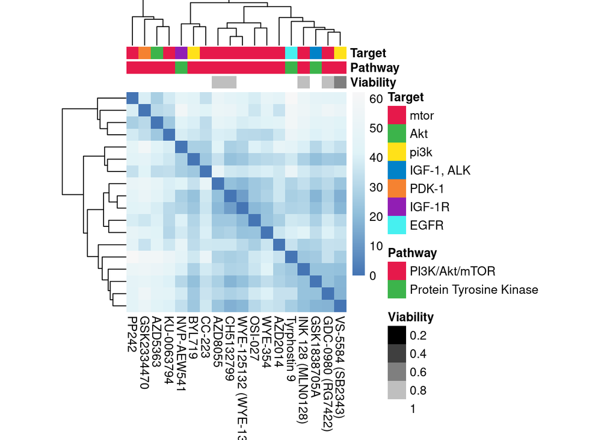

```r
line = "D004T01"
line_annotation = line_results[[line]]$Annotation
line_profiles = profiles_active[annotation$Line == line,]
line_color = anno_colorScale
if(sum(!is.na(line_annotation$Pathway)) == 0) line_annotation$Pathway = NULL
if(sum(!is.na(line_annotation$Target)) == 0) line_annotation$Target = NULL
for(column in colnames(line_annotation)) {
  if(column %in% names(line_color)) next
  entries = na.omit(unique(line_annotation[[column]]))
  line_color[[column]] = setNames(
    object = unname(colorScale)[seq_along(entries)],
    nm = entries)
}
d = line_results[[line]]$Distances
hc = line_results[[line]]$Clustering
hc_pca = line_results[[line]]$PCAClustering

labels = cutree(tree = hc, k = 2)
mtor_label = unique(labels[which(line_annotation$Target == "mtor")])
if(length(mtor_label) != 1) stop(
  "Critical Error with mTOR label for D004T01")
mtor_drugs = names(which(labels == mtor_label))

mtor_annotation = annotation[mtor_drugs, ]
mtor_annotation$Target = ifelse(
  test = !is.na(line_annotation[mtor_drugs, "Target"]),
  yes = line_annotation[mtor_drugs, "Target"],
  no = mtor_annotation[mtor_drugs, "Target"])
mtor_annotation$Line = NULL
mtor_annoColor = anno_colorScale
if(sum(!is.na(mtor_annotation$Pathway)) == 0) mtor_annotation$Pathway = NULL
if(sum(!is.na(mtor_annotation$Target)) == 0) mtor_annotation$Target = NULL
for(column in colnames(mtor_annotation)) {
  if(column %in% names(mtor_annoColor)) next
  entries = na.omit(unique(mtor_annotation[[column]]))
  mtor_annoColor[[column]] = setNames(
    object = unname(colorScale)[seq_along(entries)],
    nm = entries)
  }

d_mtor = d[labels == mtor_label, labels == mtor_label]
hc_mtor = hclust(as.dist(d_mtor), "ward.D2")

hm_colorscale = colorRampPalette(
    rev(c("#f7f7f7", "#E0F3F8", "#91BFDB", "#4575B4")))(150)

drugnames = substr(mtor_drugs, 9, 100)

pheatmap(
  mat = d_mtor, color = hm_colorscale,
  annotation_col = mtor_annotation, annotation_colors = mtor_annoColor,
  cluster_rows = hc_mtor, cluster_cols = hc_mtor, labels_col = drugnames,
  show_rownames = FALSE, cellwidth = 10, cellheight = 10, border_color = NA,
  height = 5)
```

```r
if(save_images) pheatmap(
  mat = d_mtor, color = hm_colorscale,
  annotation_col = mtor_annotation, annotation_colors = mtor_annoColor,
  cluster_rows = hc_mtor, cluster_cols = hc_mtor, labels_col = drugnames,
  show_rownames = FALSE, cellwidth = 10, cellheight = 10, border_color = NA,
  height = 10, filename = file.path(img_out_dir, sprintf(
    "EffectVectorHeatmap_Detailed_%s.pdf", line)))
```

## Enrichment Heatmap

I look at enrichment heatmaps, i.e. which cell lines have an enrichment in which pathways / targets.

### Log-Odds Heatmap

I create a heatmap of the enrichment (log odds ratio) to determine which pathways and targets are enriched in each cell line

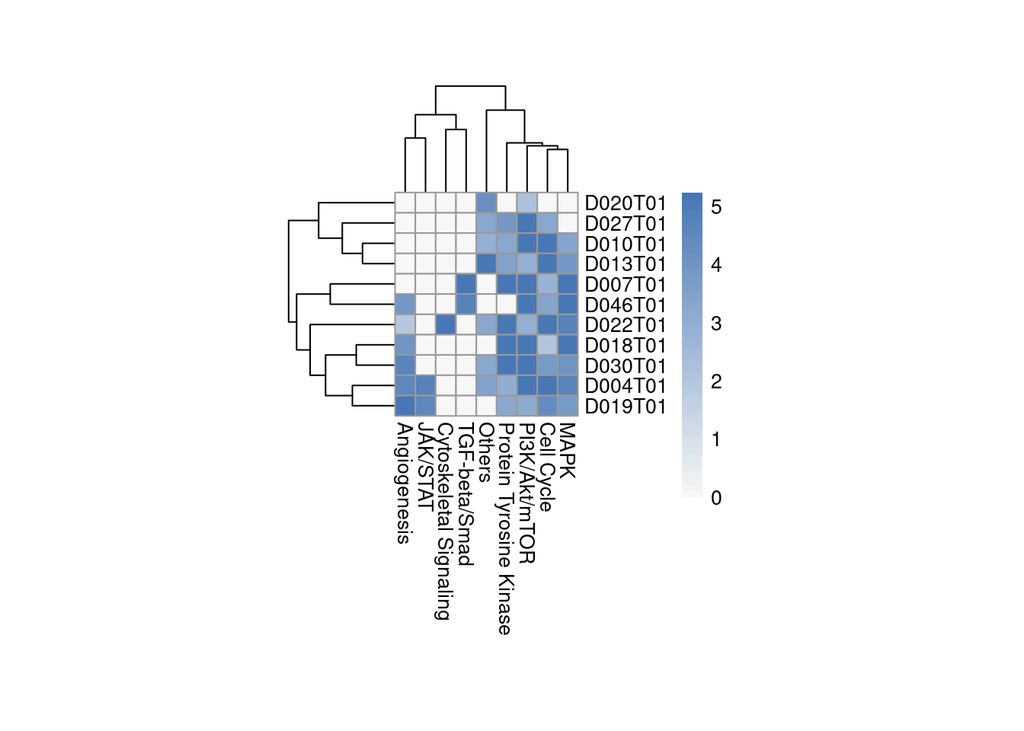

```r
heatmap_pathways = oddsratio_pathway[, c("Line", "Label", "OddsRatio")] %>% filter(!Line %in% c("D021T01", "D054T01", "D055T01", "D020T02"))

heatmap_pathways = acast(
  data = heatmap_pathways,
  formula = Line ~ Label, value.var = "OddsRatio",
  fun.aggregate = max, fill = 0)
# Replace Inf with the finite maximum
heatmap_pathways[is.infinite(heatmap_pathways)] = max(
  heatmap_pathways[!is.infinite(heatmap_pathways)])
heatmap_pathways[heatmap_pathways != 0] = log2(
  heatmap_pathways[heatmap_pathways != 0])
hc_pathways = as.dist((1 - cor(heatmap_pathways)) / 2)
hc_pathways_line = as.dist((1 - cor(t(heatmap_pathways))) / 2)

heatmap_targets = oddsratio_target[, c("Line", "Label", "OddsRatio")] %>% filter(!Line %in% c("D021T01", "D054T01", "D055T01", "D020T02"))

heatmap_targets = acast(
  data = heatmap_targets,
  formula = Line ~ Label, value.var = "OddsRatio",
  fun.aggregate = max, fill = 0)
# Replace Inf with the finite maximum
heatmap_targets[is.infinite(heatmap_targets)] = max(
  heatmap_targets[!is.infinite(heatmap_targets)])
heatmap_targets[heatmap_targets != 0] = log2(
  heatmap_targets[heatmap_targets != 0])
hc_targets = as.dist((1 - cor(heatmap_targets)) / 2)
hc_targets_line = as.dist((1 - cor(t(heatmap_targets))) / 2)

# hm_colorscale = colorRampPalette(
#   c('#b2182b','#d6604d','#f4a582', '#f7f7f7','#f7f7f7', '#f7f7f7',
#     '#f7f7f7', '#f7f7f7', '#f7f7f7'))(150)

hm_breaks = seq(0, max(heatmap_pathways, na.rm = TRUE), length.out = 50)
hm_colorscale = colorRampPalette(c("#f7f7f7", "#4575B4"))(length(hm_breaks))
pheatmap(
  heatmap_pathways, cluster_rows = hc_pathways_line,
  cluster_cols = hc_pathways,
  breaks = hm_breaks, color = hm_colorscale,
  cellwidth = 10, cellheight = 10)
```

```r
if(save_images) {
  pheatmap(
    heatmap_pathways, cluster_rows = hc_pathways_line,
    cluster_cols = hc_pathways,
    breaks = hm_breaks, color = hm_colorscale,
    cellwidth = 10, cellheight = 10,
    filename = file.path(img_out_dir, "Heatmap_LogOdds_Pathways.pdf"))
}

hm_breaks = seq(0, max(heatmap_targets, na.rm = TRUE), length.out = 50)
hm_colorscale = colorRampPalette(c("#f7f7f7", "#4575B4"))(length(hm_breaks))
pheatmap(
  heatmap_targets, cluster_rows = hc_targets_line,
  cluster_cols = hc_targets,
  breaks = hm_breaks, color = hm_colorscale,
  cellwidth = 10, cellheight = 10)
if(save_images) {
  pheatmap(
    heatmap_targets, cluster_rows = hc_targets_line,
    cluster_cols = hc_targets,
    breaks = hm_breaks, color = hm_colorscale,
    cellwidth = 10, cellheight = 10,
    filename = file.path(img_out_dir, "Heatmap_LogOdds_Targets.pdf"))
}
```

### Binary Heatmap

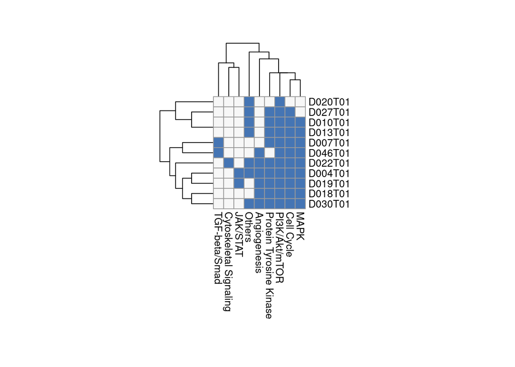

```r
binary_heatmap_pathways = heatmap_pathways
binary_heatmap_pathways[binary_heatmap_pathways > 0] = 1
binary_heatmap_targets = heatmap_targets
binary_heatmap_targets[binary_heatmap_targets > 0] = 1

hm_colorscale = colorRampPalette(c("#f7f7f7", "#4575B4"))(2)
pheatmap(
  binary_heatmap_pathways, cluster_rows = hc_pathways_line,
  cluster_cols = hc_pathways,
  color = hm_colorscale, legend = FALSE,
  cellwidth = 10, cellheight = 10)
```

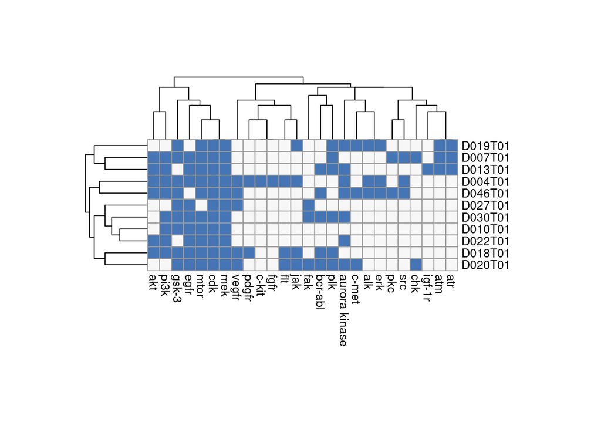

```r
pheatmap(
  binary_heatmap_targets, cluster_rows = hc_targets_line,
  cluster_cols = hc_targets,
  color = hm_colorscale, legend = FALSE,
  cellwidth = 10, cellheight = 10)
```

```r
if(save_images) {
  pheatmap(
    binary_heatmap_pathways, cluster_rows = hc_pathways_line,
    cluster_cols = hc_pathways,
    color = hm_colorscale, legend = FALSE,
    cellwidth = 10, cellheight = 10,
    filename = file.path(img_out_dir, "Heatmap_Binary_Pathways.pdf"))
  pheatmap(
    binary_heatmap_targets, cluster_rows = hc_targets_line,
    cluster_cols = hc_targets,
    color = hm_colorscale, legend = FALSE,
    cellwidth = 10, cellheight = 10,
    filename = file.path(img_out_dir, "Heatmap_Binary_Targets.pdf"))
}
```

## Feature Differences

I look at the vectors from median DMSO to median drug features for each drug per replicate. I use the well-averaged features to improve loading times. For each line, I aggregate all drugs belonging to the enriched clusters.

```r
# Extract only key features
key_features = c(
  "x.0.s.area_expected" = "Area",
  "x.0.m.eccentricity_expected" = "Eccentricity",
  "x.a.b.q05_expected" = "Median Actin Intensity",
  "x.b.b.q05_expected" = "Median FITC Intensity",
  "x.c.b.q05_expected" = "Median DAPI Intensity")

# Set up color scale
pheno_color_scale = c(
  "Median Actin Intensity" = "#e6194b",
  "Median FITC Intensity" = "#3cb44b",
  "Median DAPI Intensity" = "#0082c8",
  "Area" = "#ffe119",
  "Eccentricity" = "#f58231")

# Load features
data("well_features", package = "SCOPEAnalysis")
well_features = well_features[, names(key_features)]

# Z-Scale features for each line and replicate
for(line in unique(well_metadata$Line)) {
  for(r in unique(well_metadata$Replicate)) {
    rep_sel = well_metadata$Line == line & well_metadata$Replicate == r
    well_features[rep_sel, ] = apply(
      X = well_features[rep_sel, ],
      MARGIN = 2, FUN = function(x) (x - median(x)) / mad(x))
  }
}

# Subtract DMSO medians for each line and replicate
for(line in unique(well_metadata$Line)) {
  for(r in unique(well_metadata$Replicate)) {
    rep_sel = well_metadata$Line == line & well_metadata$Replicate == r
    rep_line_dmso_median = apply(
      X = well_features[rep_sel & well_metadata$Drug == "DMSO", ],
      MARGIN = 2, FUN = median, na.rm = TRUE)
    well_features[rep_sel, ] = sweep(
      x = well_features[rep_sel, ],
      MARGIN = 2, STATS = rep_line_dmso_median, FUN = "-")
  }
}

# Aggregate features for pathways for each line and replicate
all_pathway_features = list()
all_target_features = list()
for(line in unique(well_metadata$Line)) {
  line_enriched_drugs = enriched_drugs[enriched_drugs$Line == line, ]
  line_enriched_pathways = unique(line_enriched_drugs[
    line_enriched_drugs$is.pathway.enriched, "Pathway"])
  line_enriched_targets = unique(line_enriched_drugs[
    line_enriched_drugs$is.target.enriched, "Enriched.Target"])

  # Pathways
  for(pathway in line_enriched_pathways) {
    drugs = line_enriched_drugs[
      line_enriched_drugs$Pathway == pathway &
      line_enriched_drugs$is.pathway.enriched, ]
    sel_indices = well_metadata$Drug %in% drugs$Drug & well_metadata$Line == line
    relevant_features = well_features[sel_indices, ]
    relevant_metadata = well_metadata[sel_indices, ]
    # Aggregate
    pathway_features = aggregate(
      x = relevant_features,
      by = list("Replicate" = relevant_metadata$Replicate),
      FUN = median)
    pathway_features$Line = line
    pathway_features$Label = pathway
    all_pathway_features[[length(all_pathway_features) + 1]] = pathway_features
  }

  # Targets
  for(target in line_enriched_targets) {
    drugs = line_enriched_drugs[
      line_enriched_drugs$Enriched.Target == target &
      line_enriched_drugs$is.target.enriched, ]
    sel_indices = well_metadata$Drug %in% drugs$Drug & well_metadata$Line == line
    relevant_features = well_features[sel_indices, ]
    relevant_metadata = well_metadata[sel_indices, ]
    # Aggregate
    target_features = aggregate(
      x = relevant_features,
      by = list("Replicate" = relevant_metadata$Replicate),
      FUN = median)
    target_features$Line = line
    target_features$Label = target
    all_target_features[[length(all_target_features) + 1]] = target_features
  }
}
all_pathway_features = do.call(rbind, all_pathway_features)
all_target_features = do.call(rbind, all_target_features)
```

### Phenoprints for Pathways

```r
for(line in unique(all_pathway_features$Line)) {
  labels = unique(all_pathway_features[
    all_pathway_features$Line == line, "Label"])
  for(label in labels) {
    ggplot_df = all_pathway_features[all_pathway_features$Line == line &
                                     all_pathway_features$Label == label, ]
    ggplot_df$Line = NULL
    ggplot_df$Label = NULL
    ggplot_df = melt(ggplot_df, id.vars = c("Replicate"))
    ggplot_df$variable = key_features[ggplot_df$variable]
    ggplot_df$variable = factor(ggplot_df$variable, levels = key_features)
    ggplot_df_bar = aggregate(
      x = ggplot_df$value,
      by = list("variable" = ggplot_df$variable),
      FUN = median)
    colnames(ggplot_df_bar) = c("variable", "value")
    gp = ggplot(mapping = aes(x = variable, y = value)) +
      geom_col(data = ggplot_df_bar, mapping = aes(fill = variable)) +
      geom_point(data = ggplot_df) +
      scale_fill_manual(values = pheno_color_scale) +
      theme_vignette() + coord_fixed() +
      theme(
        axis.text.x = element_blank(), axis.line.x = element_blank(),
        axis.ticks.x = element_blank(), legend.title = element_blank()) +
      xlab("") + ylab("") + ggtitle(paste0(line, " ", label))
    plot(gp)
    if(save_images) ggsave(
      filename = file.path(img_out_dir, sprintf(
        "Phenoprints_Pathways_%s_%s.pdf", line, make.names(label))),
      width = 5, height = 5, useDingbats = FALSE)
  }
}
```

### Phenoprints for Targets

```r
for(line in unique(all_target_features$Line)) {
  labels = unique(all_target_features[
    all_target_features$Line == line, "Label"])
  for(label in labels) {
    ggplot_df = all_target_features[all_target_features$Line == line &
                                     all_target_features$Label == label, ]
    ggplot_df$Line = NULL
    ggplot_df$Label = NULL
    ggplot_df = melt(ggplot_df, id.vars = c("Replicate"))
    ggplot_df$variable = key_features[ggplot_df$variable]
    ggplot_df$variable = factor(ggplot_df$variable, levels = key_features)
    ggplot_df_bar = aggregate(
      x = ggplot_df$value,
      by = list("variable" = ggplot_df$variable),
      FUN = median)
    colnames(ggplot_df_bar) = c("variable", "value")
    gp = ggplot(mapping = aes(x = variable, y = value)) +
      geom_col(data = ggplot_df_bar, mapping = aes(fill = variable)) +
      geom_point(data = ggplot_df) +
      scale_fill_manual(values = pheno_color_scale) +
      theme_vignette() + coord_fixed() +
      theme(
        axis.text.x = element_blank(), axis.line.x = element_blank(),
        axis.ticks.x = element_blank(), legend.title = element_blank()) +
      xlab("") + ylab("") + ggtitle(paste0(line, " ", label))
    plot(gp)
    if(save_images) ggsave(
      filename = file.path(img_out_dir, sprintf(
        "Phenoprints_Targets_%s_%s.pdf", line, make.names(label))),
      width = 5, height = 5, useDingbats = FALSE)
  }
}
```

## Drug Effect Differences across all Lines

### Comparing Drug Effects Directly

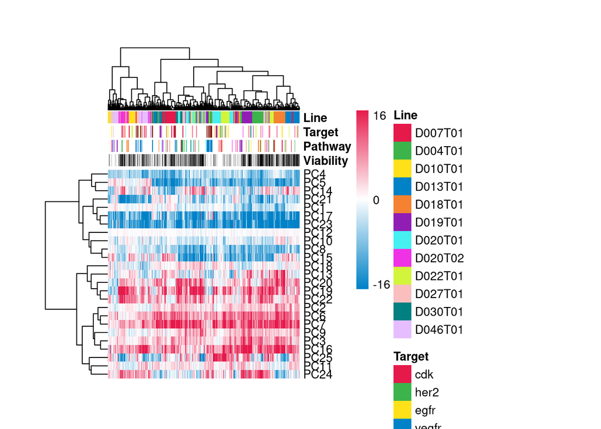

```r
## overwriting objects to remove dropped lines
profiles_active <- profiles_active %>% rownames_to_column("id") %>% mutate(line = substr(id, 1, 7)) %>%
  dplyr::filter(!line %in% c("D021T01", "D054T01", "D055T01")) %>% dplyr::select(-line) %>%
  column_to_rownames("id")

angles = get_angles(profiles_active)
d = acos(angles)*180/pi
hc = hclust(as.dist(d), method = "ward.D2")

cor_pca = cor(profiles_active)
d_pca = as.dist((1 - cor_pca) / 2)
hc_pca = hclust(d_pca, method = "ward.D2")

killing_anno = rep(NA, nrow(metadata_active))
killing_anno[metadata_active$Viability <= 0.2] = "0.2"
killing_anno[
  metadata_active$Viability > 0.2 &
  metadata_active$Viability <= 0.4] = "0.4"
killing_anno[
  metadata_active$Viability > 0.4 &
  metadata_active$Viability <= 0.6] = "0.6"
killing_anno[
  metadata_active$Viability > 0.6 &
  metadata_active$Viability <= 0.8] = "0.8"
killing_anno[
  metadata_active$Viability > 0.8 &
  metadata_active$Viability <= 1] = "1"

annotation = data.frame(
  "Viability" = killing_anno,
  "Pathway" = get_mode_of_action(metadata_active$Drug),
  "Target" = get_targets(metadata_active$Drug),
  "Line" = metadata_active$Line,
  #row.names = rownames(profiles_active),
  stringsAsFactors = FALSE)

# dropping lines
annotation <- annotation %>% dplyr::filter(!Line %in% c("D021T01", "D054T01", "D055T01"))
rownames(annotation) <- rownames(profiles_active)

# Annotate Pathway and Targets
pathways = list()
for(pathway in unique(annotation$Pathway)) {
  pathways[[pathway]] = grep(
    pattern = paste0("\\b", pathway, "\\b"),
    x = annotation$Pathway,
    ignore.case = TRUE)
}
# My cluster_enrichment function doesn't play well with NA values yet
pathways = pathways[!is.na(names(pathways))]
pathways_sig_vec = get_cluster_enrichment(
  clustering = hc, labels = pathways, min_cluster_size = min_cluster_size)
# 'Others' is too vague
pathways_sig_vec$Labels[pathways_sig_vec$Labels == "Others"] = NA

targets_split = tolower(annotation$Target)
targets = list()
for(target in unique(unlist(strsplit(targets_split, ", ")))) {
  targets[[target]] = grep(
    pattern = paste0("\\b", target, "\\b"),
    x = targets_split, ignore.case = TRUE)
}
# My cluster_enrichment function doesn't play well with NA values yet
targets = targets[!is.na(names(targets))]
targets_sig_vec = get_cluster_enrichment(
  clustering = hc, labels = targets, min_cluster_size = min_cluster_size)

annotation$Pathway = pathways_sig_vec$Labels
annotation$Target = targets_sig_vec$Labels

# Set up colors
anno_colorScale = list(
  "Viability" = setNames(
    object = colorRampPalette(c("black", "white"))(
      length(unique(annotation$Viability))),
    nm = sort(unique(annotation$Viability))))
if(sum(!is.na(annotation$Pathway)) == 0) annotation$Pathway = NULL
if(sum(!is.na(annotation$Target)) == 0) annotation$Target = NULL
for(column in colnames(annotation)) {
  if(column %in% names(anno_colorScale)) next
  entries = na.omit(unique(annotation[[column]]))
  anno_colorScale[[column]] = setNames(
    object = unname(colorScale)[seq_along(entries)],
    nm = entries)
}

# Set up heatmap color scale
sqrt_profiles = profiles_active
sqrt_profiles[sqrt_profiles > 0] = sqrt(sqrt_profiles[sqrt_profiles > 0])
sqrt_profiles[sqrt_profiles < 0] = -sqrt(-sqrt_profiles[sqrt_profiles < 0])
hm_range_limit = max(abs(sqrt_profiles))
hm_breaks = seq(-hm_range_limit, hm_range_limit, length.out = 100)
hm_legend_breaks = c(-floor(hm_range_limit), 0, floor(hm_range_limit))
hm_legend_labels = hm_legend_breaks**2
hm_legend_labels[hm_legend_breaks < 0] = -hm_legend_labels[hm_legend_breaks < 0]
hm_colorscale = colorRampPalette(
  c("#0082c8", "white", "#e6194b"))(length(hm_breaks))

pheatmap(
  mat = t(profiles_active), cluster_rows = hc_pca, cluster_cols = hc,
  show_colnames = FALSE, annotation_col = annotation, breaks = hm_breaks,
  legend_breaks = hm_legend_breaks, legend_labels = hm_legend_labels,
  color = hm_colorscale, annotation_colors = anno_colorScale,
  cellwidth = 0.1, cellheight = 7)
```

```r
if(save_images) pheatmap(
  mat = t(profiles_active), cluster_rows = hc_pca, cluster_cols = hc,
  show_colnames = FALSE, annotation_col = annotation, breaks = hm_breaks,
  legend_breaks = hm_legend_breaks, legend_labels = hm_legend_labels,
  color = hm_colorscale, annotation_colors = anno_colorScale,
  cellwidth = 0.2, cellheight = 7, width = 10, height = 10,
  filename = file.path(
    img_out_dir, "EffectVectorHeatmap_allDrugs_noConcat_PCA.pdf"))

 hm_colorscale = colorRampPalette(
    rev(c("#f7f7f7", "#f7f7f7", "#f7f7f7",
          "#E0F3F8", "#91BFDB", "#4575B4")))(150)

pheatmap(
  mat = d, cluster_rows = hc, cluster_cols = hc, color = hm_colorscale,
  show_colnames = FALSE, show_rownames = FALSE,
  annotation_col = annotation, annotation_colors = anno_colorScale,
  cellwidth = 0.1, cellheight = 0.1)
if(save_images) pheatmap(
  mat = d, cluster_rows = hc, cluster_cols = hc, color = hm_colorscale,
  show_colnames = FALSE, show_rownames = FALSE,
  annotation_col = annotation, annotation_colors = anno_colorScale,
  cellwidth = 0.1, cellheight = 0.1, height = 10,
  filename = file.path(
    img_out_dir, "EffectVectorHeatmap_allDrugs_noConcat.pdf"))
```

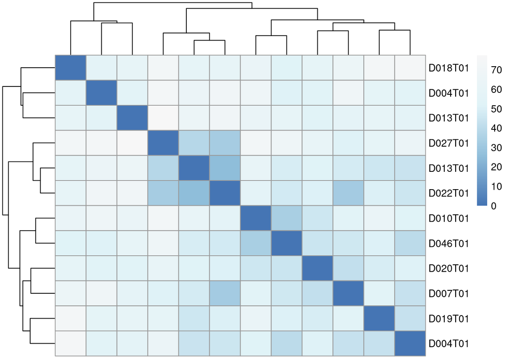

```r
sel_indices = metadata_active$Drug == "AZD2014"
drug_profiles = profiles_active[sel_indices, ]
drug_annotation = annotation[sel_indices, ]

angles_drug = get_angles(drug_profiles)
d_drug = acos(angles_drug) * 180 / pi
hc_drug = hclust(as.dist(d_drug), method = "ward.D2")

hm_colorscale = colorRampPalette(
  rev(c("#f7f7f7", "#E0F3F8", "#91BFDB", "#4575B4")))(150)

pheatmap(
  mat = d_drug, cluster_rows = hc_drug, cluster_cols = hc_drug,
  color = hm_colorscale, labels_row = drug_annotation$Line,
  show_colnames = FALSE)
```

### Concatenating Vectors

Instead of treating each drug per line separately, I concatenate the effect vectors on all lines for each drug. The resulting composite vector describes the drug’s effect on all cell lines without attempting to compare cell lines.

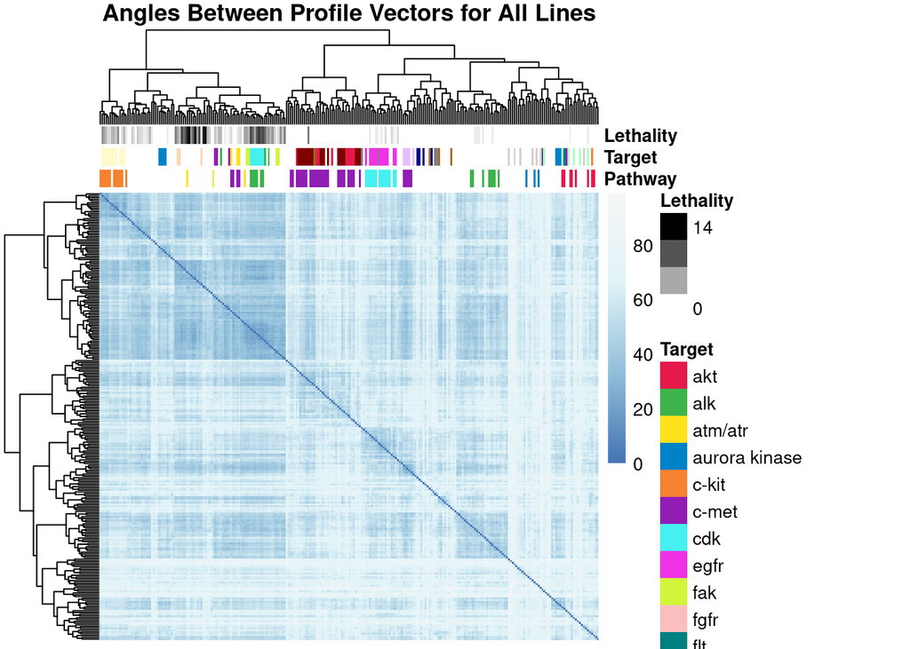

```r
## TODO dropping filtered line
loi <- sort(unique(metadata_active$Line))[!c(sort(unique(metadata_active$Line))%in% c("D021T01", "D055T01", "D054T01"))]

profiles_concat = list()
for(drug in sort(unique(metadata_active$Drug))) {
# for(drug in sort(unique(metadata$Drug))) {
  profiles_concat_drug = c()
  for(line in loi) {
  # for(line in sort(unique(metadata$Line))) {
    tmp = profiles[
      metadata$Drug == drug &
      metadata$Line == line, , drop = FALSE]
    if(is.null(nrow(tmp))) stop("Critical Error: the code expects a matrix")
    if(nrow(tmp) == 0) {
      tmp = matrix(
        data = NA, nrow = 1, ncol = n_components,
        dimnames = list(drug, paste0(line, ".", colnames(tmp))))
    } else if(nrow(tmp) > 1) {
      tmp = matrix(
        colMeans(tmp), nrow=1,
        dimnames = list(drug, paste0(line, ".", colnames(tmp))))
    } else {
      rownames(tmp) = drug
      colnames(tmp) = paste0(line, ".", colnames(tmp))
    }
    profiles_concat_drug = cbind(profiles_concat_drug, as.matrix(tmp))
  }
  profiles_concat[[drug]] = data.frame(
    profiles_concat_drug)
}
profiles_concat = do.call(rbind, profiles_concat)

# Impute missing values with the means for the corresponding PC of all other
# lines for that drug
missing_drugs = which(is.na(profiles_concat), arr.ind = T)
for(ii in seq_len(nrow(missing_drugs))) {
  entry = missing_drugs[ii, ]
  pc = strsplit(colnames(profiles_concat)[entry[2]], ".", fixed = TRUE)[[1]][2]
  other_pc_cols = sapply(
    strsplit(colnames(profiles_concat), ".", fixed = TRUE),
    "[[", 2) == pc
  mean_val = mean(as.numeric(
    profiles_concat[entry[1], other_pc_cols]), na.rm = TRUE)
  profiles_concat[entry[1], entry[2]] = mean_val
}

# If a drug has no effect in a line, I set its respective PC values to 0
# for(drug in rownames(profiles_concat)) {
#   for(line in sort(unique(metadata_active$Line))) {
#     drug_is_active = metadata$AUC_Mean[
#       metadata$Line == line &
#       metadata$Drug == drug] >= auc_thresh
#     if(length(drug_is_active) == 0) next
#     if(!drug_is_active) profiles_concat[
#       drug, substr(colnames(profiles_concat), 1, 7) == line] = 0
#   }
# }

# Cluster
angles = get_angles(profiles_concat)
d = acos(angles) * 180 / pi
hc = hclust(as.dist(d), method = "ward.D2")

annotation = data.frame(
  "Pathway" = get_mode_of_action(rownames(profiles_concat)),
  "Target" = get_targets(rownames(profiles_concat)),
  row.names = rownames(profiles_concat),
  stringsAsFactors = FALSE)

# Annotate Pathway and Targets
pathways = list()
for(pathway in unique(annotation$Pathway)) {
  pathways[[pathway]] = grep(
    pattern = paste0("\\b", pathway, "\\b"),
    x = annotation$Pathway,
    ignore.case = TRUE)
}
pathways_sig_vec = get_cluster_enrichment(
  clustering = hc, labels = pathways, min_cluster_size = min_cluster_size)
# 'Others' is too vague
pathways_sig_vec$Labels[pathways_sig_vec$Labels == "Others"] = NA

targets_split = tolower(annotation$Target)
targets = list()
for(target in unique(unlist(strsplit(targets_split, ", ")))) {
  targets[[target]] = grep(
    pattern = paste0("\\b", target, "\\b"),
    x = targets_split, ignore.case = TRUE)
}
targets_sig_vec = get_cluster_enrichment(
  clustering = hc, labels = targets, min_cluster_size = min_cluster_size)

annotation$Pathway = pathways_sig_vec$Labels
annotation$Target = targets_sig_vec$Labels

if(sum(!is.na(annotation$Pathway)) == 0) annotation$Pathway = NULL
if(sum(!is.na(annotation$Target)) == 0) annotation$Target = NULL

# Add a summary statistic for lethality
lethality_degree = aggregate(
  x = metadata$Viability <= 0.25,
  by = list("Drug" = metadata$Drug),
  FUN = sum)
rownames(lethality_degree) = lethality_degree$Drug
lethality_degree$Drug = NULL
# Hack to normalize number of lethal lines for positive controls
lethality_degree$x[lethality_degree$x > length(unique(metadata$Line))] = length(unique(metadata$Line))
annotation$Lethality = lethality_degree[rownames(annotation), "x"]

# Set up colors
anno_colorScale = list()
for(column in colnames(annotation)) {
  if(column %in% names(anno_colorScale)) next
  entries = sort(na.omit(unique(annotation[[column]])))
  anno_colorScale[[column]] = setNames(
    object = unname(colorScale)[seq_along(entries)],
    nm = entries)
}
anno_colorScale$Lethality = colorRampPalette(
  c("white", "black"))(length(anno_colorScale$Lethality))

# hm_colorscale = colorRampPalette(
#   rev(c("#f7f7f7", "#f7f7f7", "#f7f7f7", "#f7f7f7",
#         "#E0F3F8", "#91BFDB", "#4575B4")))(150)

hm_colorscale = colorRampPalette(
  rev(c("#f7f7f7", "#E0F3F8", "#91BFDB", "#4575B4")))(150)

anno_colorScale$Target = setNames(
  object = c("#e6194b", "#3cb44b", "#ffe119", "#0082c8", "#f58231",
             "#911eb4", "#46f0f0", "#f032e6", "#d2f53c", "#fabebe",
             "#008080", "#e6beff", "#aa6e28", "#fffac8", "#800000",
             "#aaffc3", "#808000", "#ffd8b1", "#000080", "#808080",
             "#d0d0d0", "#000000"),
  nm = names(anno_colorScale$Target))

pheatmap(
    mat = d, annotation_col = annotation,
    color = hm_colorscale, annotation_colors = anno_colorScale,
    show_rownames = FALSE, show_colnames = FALSE,
    cluster_rows = hc, cluster_cols = hc,
    main = "Angles Between Profile Vectors for All Lines",
    border_color = NA)
```

```r
if(save_images) pheatmap(
    d, annotation_col = annotation,
    color = hm_colorscale, annotation_colors = anno_colorScale,
    show_rownames = FALSE, show_colnames = FALSE,
    cluster_rows = hc, cluster_cols = hc,
    main = sprintf("Angles Between Profile Vectors for all lines"),
    border_color = NA, cellwidth = 1.5, cellheight = 1.5, height = 15,
    filename = file.path(img_out_dir, "EffectVectorHeatmap_allDrugs.pdf"))

if(save_images) pheatmap(
    d, annotation_col = annotation,
    color = hm_colorscale, annotation_colors = anno_colorScale,
    show_rownames = TRUE, show_colnames = FALSE,
    cluster_rows = hc, cluster_cols = hc,
    main = sprintf("Angles Between Profile Vectors for all lines"),
    border_color = NA, cellwidth = 1.5, cellheight = 15, height = 150,
    filename = file.path(img_out_dir, "EffectVectorHeatmap_allDrugs_large.pdf"))
```

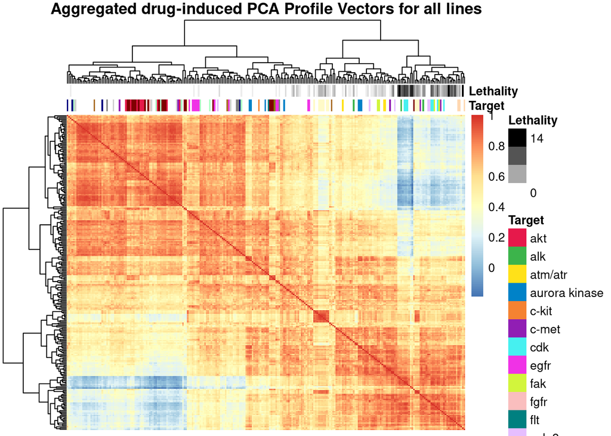

```r
active_drugs = rownames(d)

drug_df <- readRDS(here::here("data/processed/morphology/pca_absolute_all_drugs_aggregate.Rds")) %>%
  mutate(rep = paste0("r", replicate)) %>%
  mutate(line = substr(line, 1, 4)) %>%
  #filter(size_log > 7.5) %>%
  group_by(line, drug) %>%
  summarise_at(vars(contains("pc")), funs(mean)) %>%
  ungroup() %>%
  gather(pca, value, -line, -drug) %>%
  mutate(feature = paste0(pca, "_", line)) %>%
  dplyr::select(-line, -pca)

active_drug_df <- drug_df %>%
  filter(drug %in% active_drugs)

drug_df_cor <- active_drug_df %>%
  spread(drug, value) %>%
  column_to_rownames("feature") %>%
  cor()

pheatmap(
    mat = drug_df_cor, annotation_col = annotation %>% dplyr::select(-Pathway),
    annotation_colors = anno_colorScale,
    show_rownames = FALSE, show_colnames = FALSE,
    #cluster_rows = hc, cluster_cols = hc,
    main = sprintf("Aggregated drug-induced PCA Profile Vectors for all lines"),
    border_color = NA)
```

```r
if(save_images) pheatmap(
    drug_df_cor, annotation_col = annotation %>% dplyr::select(-Pathway),
    #color = hm_colorscale,
    annotation_colors = anno_colorScale,
    show_rownames = FALSE, show_colnames = FALSE,
    #cluster_rows = hc, cluster_cols = hc,
    main = sprintf("Aggregated drug-induced PCA Profile Vectors for all lines"),
    border_color = NA, cellwidth = 1.5, cellheight = 1.5, height = 15,
    filename = file.path(img_out_dir, "aggregate_pca_heatmap_allDrugs.pdf"))

if(save_images) pheatmap(
    drug_df_cor, annotation_col = annotation %>% dplyr::select(-Pathway),
    #color = hm_colorscale,
    annotation_colors = anno_colorScale,
    show_rownames = TRUE, show_colnames = FALSE,
    #cluster_rows = hc, cluster_cols = hc,
    main = sprintf("Aggregated drug-induced PCA Profile Vectors for all lines"),
    border_color = NA, cellwidth = 1.5, cellheight = 15, height = 150,
    filename = file.path(img_out_dir, "aggregate_pca_heatmap_allDrugs_large.pdf"))
```

Shown are the individual drug viabilities for each line according to the clustering for the drug effects to further showcase the compatibility between the methods

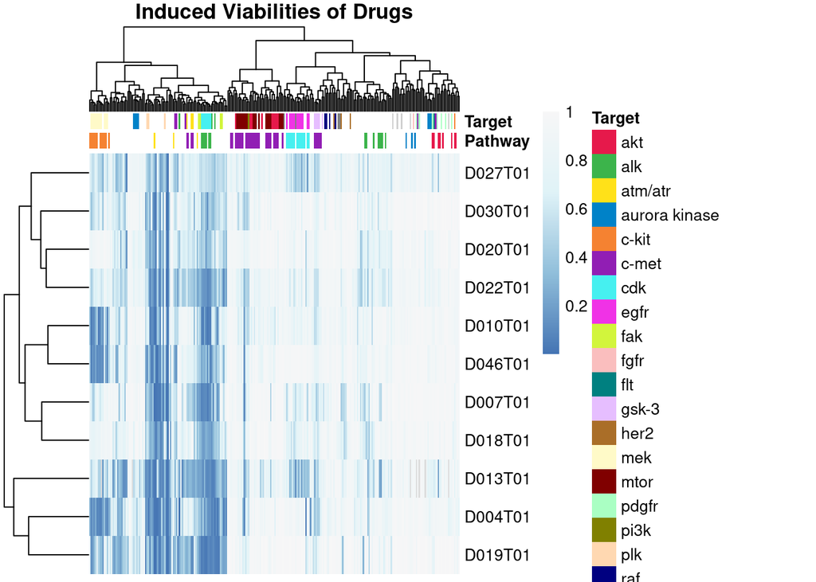

```r
active_drugs = rownames(d)
active_viabilities = metadata[metadata$Drug %in% active_drugs, ]

# Aggregate drugs over wells
active_viabilities = aggregate(
  x = active_viabilities$Viability,
  by = list("Drug" = active_viabilities$Drug,
            "Line" = active_viabilities$Line),
  FUN = median, na.rm = TRUE)

active_viabilities = acast(
  data = active_viabilities,
  formula = Line ~ Drug, value.var = "x")

## TODO drop lines
active_viabilities = active_viabilities[!c(active_viabilities %>% rownames() %in% c("D021T01", "D055T01", "D054T01",
                                                                                    "D020T02")),]

# Remove viability from annotation
anno_noLethality = annotation
anno_noLethality$Lethality = NULL
anno_colorScale$Lethality = NULL

pheatmap(
    mat = active_viabilities, annotation_col = anno_noLethality,
    color = hm_colorscale, annotation_colors = anno_colorScale,
    show_rownames = TRUE, show_colnames = FALSE,
    cluster_rows = TRUE, cluster_cols = hc,
    main = "Induced Viabilities of Drugs",
    border_color = NA)
```

```r
if(save_images) pheatmap(
    mat = active_viabilities, annotation_col = anno_noLethality,
    color = hm_colorscale, annotation_colors = anno_colorScale,
    show_rownames = TRUE, show_colnames = FALSE,
    cluster_rows = TRUE, cluster_cols = hc,
    main = "Induced Viabilities of Drugs",
    border_color = NA, cellwidth = 1.5, cellheight = 10, height = 15,
    filename = file.path(img_out_dir, "EffectVectorHeatmap_Viabilities_allDrugs.pdf"))
```

Generate a list of column/row names with annotations

```r
annotation_table = annotation[hc$labels[hc$order], ]
colnames(annotation_table) = c(
  "EnrichedPathway", "EnrichedTarget", "Lethality")
annotation_table$Pathway = get_mode_of_action(rownames(annotation_table))
annotation_table$Targets = tolower(get_targets(rownames(annotation_table)))
annotation_table = annotation_table[, c(
  "Pathway", "Targets", "EnrichedPathway", "EnrichedTarget", "Lethality")]
print(annotation_table)
```

```
##                                                       Pathway
## Ulixertinib (BVD-523, VRT752271)                         MAPK
## TAK-733                                                  MAPK
## Trametinib (GSK1120212)                                  MAPK
## Cobimetinib (GDC-0973, RG7420)                           MAPK
## MEK162 (ARRY-162, ARRY-438162)                           MAPK
## Selumetinib (AZD6244)                                    MAPK
## Refametinib (RDEA119, Bay 86-9766)                     Others
## AZD8330                                                  MAPK
## Pimasertib (AS-703026)                                   MAPK
## RAF265 (CHIR-265)                                        MAPK
## PD184352 (CI-1040)                                       MAPK
## PD318088                                                 MAPK
## PD0325901                                          DNA Damage
## VX-11e                                                   MAPK
## Alisertib (MLN8237)                                    Others
## GSK2292767                                      PI3K/Akt/mTOR
## Hesperadin                                         Cell Cycle
## KW-2449                                          Angiogenesis
## PF-4708671                                      PI3K/Akt/mTOR
## BMS-754807                                             Others
## LY3023414                                       PI3K/Akt/mTOR
## Crizotinib (PF-02341066)                               Others
## ENMD-2076                                        Angiogenesis
## HMN-214                                            Cell Cycle
## BKM120 (NVP-BKM120, Buparlisib)                 PI3K/Akt/mTOR
## NVP-AEW541                            Protein Tyrosine Kinase
## AZ 960                                               JAK/STAT
## GSK2636771                                      PI3K/Akt/mTOR
## RepSox                                          TGF-beta/Smad
## Foretinib (GSK1363089)                                 Others
## Danusertib (PHA-739358)                                Others
## SNS-314 Mesylate                                       Others
## CYC116                                             Cell Cycle
## VX-680 (Tozasertib, MK-0457)         Endocrinology & Hormones
## AZD1480                                              JAK/STAT
## BX-912                                          PI3K/Akt/mTOR
## PD173955                                         Angiogenesis
## TPCA-1                                                  NF-_B
## AZD7762                                            Cell Cycle
```

[output cut: 957 more lines]

```
## Bosutinib (SKI-606)                          1
## PRT062607 (P505-15, BIIB057) HCl             0
## Sorafenib Tosylate                           0
## WH-4-023                                     0
## AG-1024                                      0
## Amuvatinib (MP-470)                          0
## Lapatinib (GW-572016) Ditosylate             0
## Cediranib (AZD2171)                          0
## U0126-EtOH                                   0
## Ponatinib (AP24534)                          1
## DASA-58                                      0
## Dasatinib                                    0
## PF-573228                                    0
## BMS-265246                                   0
## KU-60019                                     0
```

Generate a force-directed graph from these similarities

```r
# Set up adjacency matrix
adjmatrix = d
adjmatrix[adjmatrix > 45] = 0

# Resort matrix to make sure annotated nodes are above unannotated ones
sort_order = order(annotation$Target, na.last = FALSE)
adjmatrix = adjmatrix[sort_order, sort_order]

# Remove drugs without any connections
sel_indices = colSums(adjmatrix != 0) != 0
adjmatrix = adjmatrix[sel_indices, sel_indices]

# Convert to cosine distance: D = 1 - cos(angle)
# adjmatrix = 1 - cos(adjmatrix * pi / 180)

# Generate network
adjmatrix = Matrix::Matrix(data = adjmatrix, sparse = TRUE)
net = graph_from_adjacency_matrix(
  adjmatrix = adjmatrix, mode = "undirected", diag = FALSE, weighted = TRUE)

# Assign targets and colors
V(net)$target = annotation[match(V(net)$name, rownames(annotation)), "Target"]
V(net)$color = V(net)$target
for(target in na.omit(unique(V(net)$target))) {
  regex = paste0("\\b", target, "\\b")
  V(net)$color = gsub(regex, anno_colorScale$Target[target], V(net)$color)}
V(net)$color[is.na(V(net)$color)] = "white"

# Assign size
V(net)$size = 5
V(net)[!is.na(V(net)$target)]$size = 7.5

# # Create plot
# e = get.edgelist(net, names = FALSE)
# l = qgraph.layout.fruchtermanreingold(
#   edgelist = e, vcount = vcount(net),
#   area=20*(vcount(net)^2), repulse.rad=(vcount(net)^3.1))
# # l = layout_with_graphopt(graph = net, niter = 1000, mass = 100)
# plot.igraph(net, vertex.label = NA, layout=l,
#             edge.width = 0.5, edge.color = "lightgray")
# if(save_images) {
#   pdf(file = file.path(img_out_dir, "EffectVectorNetwork_allLines.pdf"),
#       width = 7, height = 7, useDingbats = FALSE)
#   plot.igraph(net, vertex.label = NA, layout=l,
#             edge.width = 0.5, edge.color = "lightgray")
#   dev.off()}
```

# Clinical Cancer Panel

```r
sel_indices = !is.na(drug_effect_metadata$Concentration)
profiles = drug_effect_profiles[sel_indices, ]
metadata = drug_effect_metadata[sel_indices, ]
# Sort for convenience
order_indices = order(rownames(profiles))
profiles = profiles[order_indices, ]
metadata = metadata[order_indices, ]
```

## Drugs Active at All Concentrations

```r
sig_concentrations = aggregate(
  x = metadata$AUC_Mean >= auc_thresh,
  by = list("Drug" = metadata$Drug,
            "Line" = metadata$Line),
  FUN = sum)

sig_conc_table = as.data.frame(table(sig_concentrations$x))
sig_conc_table$TextLoc = sig_conc_table$Freq - 50
ggplot(data = sig_conc_table) +
  geom_col(mapping = aes(x = Var1, y = Freq)) + theme_vignette() +
  geom_text(mapping = aes(x = Var1, y = TextLoc, label = Freq),
            color = "white", fontface = "bold", size = 3) +
  xlab("Active Concentrations") + ylab("Number of Drugs") + coord_flip() +
  theme(axis.line = element_blank(), axis.text.x = element_blank(),
        axis.ticks = element_blank())
if(save_images) ggsave(
  filename = file.path(img_out_dir, "Barplot_NumActiveConcentrations.pdf"),
  width = 2.5, height = 3)


# The number of concentrations at which drugs should be active
conc_thresh = 5
sig_concentrations = sig_concentrations[
  sig_concentrations$x >= conc_thresh, ]

# Create heatmap for each entry
for(ii in seq_len(nrow(sig_concentrations))) {
  drug = sig_concentrations[ii, "Drug"]
  line = sig_concentrations[ii, "Line"]
  sel_indices = metadata$Line == line & metadata$Drug == drug
  entry = profiles[sel_indices, ]
  entry_md = metadata[sel_indices, ]

  angles = get_angles(entry)
  d = acos(angles)*180/pi
  hc = hclust(as.dist(d), method = "ward.D2")

  hm_colorscale = colorRampPalette(
    rev(c("#f7f7f7", "#E0F3F8", "#91BFDB", "#4575B4")))(150)

  pheatmap(
    d, cluster_rows = hc, cluster_cols = hc, color = hm_colorscale,
    display_numbers = round(d), cellwidth = 20, cellheight = 20,
    labels_row = entry_md$Concentration, show_colnames = FALSE,
    main = paste0(line, " - ", drug))
}
```